# Assignment 7

Kyle Walker

10/23/2019

#### 1. Write a function: input a number x and return x^2 + 3x + 1

```r
quad <- function(x) {
  return( x^2 + 3*x + 1)
}
quad(2)
```

```
## [1] 11
```

#### 2. Not using loops, write a function: input a vector and return the product of all the entries in the vector.

```r
prod_vect <- function(x) {
  prod(x)
}

test <- c(1,2,3,4,5)

prod_vect(test)
```

```
## [1] 120
```

#### 3. Using loops, write a function: input a vector and return the product of all the entries in the vector.

```r
prod_loop <- function(x) {
  product <- 1
  for (i in x) {
    product <- product * i
  }
  return(product)
}

test <- c(1:10)

prod_loop(test)
```

```
## [1] 3628800
```

#### 4. Use the above approach to write to caculate or plot

#### • (a) the rows sum squares of matrix x above.

```r
x = matrix(c(1:9), nrow=3)

apply(x, MARGIN = 1, function(y){sum(y^2)})
```

```
## [1]  66  93 126
```

#### • (b) the row sums of positive entries in y, where y is a 100x100 matrix with the entries following standard normal distribution.

```r
y = matrix(rnorm(10000), nrow=100)

apply(y, MARGIN = 1, function(x){
      z <- 0
      for (i in x) {
          if(i > 0) {
            z <- z + i
          }
          else {
            z <- z
          }
      }
      z
  }
)
```

```
##   [1] 33.89682 38.89339 44.51517 43.13231 39.55778 45.89765 40.19772
##   [8] 39.33467 34.16979 42.31189 42.85606 44.35298 46.65850 38.74138
##  [15] 49.79524 39.59608 40.42595 43.11018 44.57745 46.65762 41.39443
##  [22] 52.20274 29.51226 33.38834 45.38617 34.18474 38.40380 35.07421
##  [29] 37.71954 41.38415 34.18361 35.04786 42.37420 30.07051 45.43316
##  [36] 46.59352 42.82294 48.14539 32.37936 51.90266 40.22979 41.64891
##  [43] 34.44667 36.55570 32.82296 35.36024 31.82490 32.24353 38.37710
##  [50] 37.97317 42.43982 41.84301 46.76013 28.33242 34.26903 39.36905
##  [57] 42.09166 43.38479 35.63441 38.71867 51.31417 39.85848 36.23993
##  [64] 44.18566 39.82947 38.32587 37.46175 49.52015 36.22913 33.37554
##  [71] 31.78013 30.37276 44.39303 38.15415 43.75782 32.81606 46.85119
##  [78] 32.24883 32.51601 50.06960 40.21172 35.98714 40.34987 28.56267
##  [85] 44.03075 29.78056 33.83378 39.90586 49.82882 29.78988 38.52945
##  [92] 38.68636 34.45416 43.17618 40.96875 30.72383 38.32566 27.15423
##  [99] 45.00354 44.06845
```

#### • (c) the row sums square of entries in y, where y is a 100x100 matrix with the entries following standard normal distribution. What is the distribution of these sum squares?

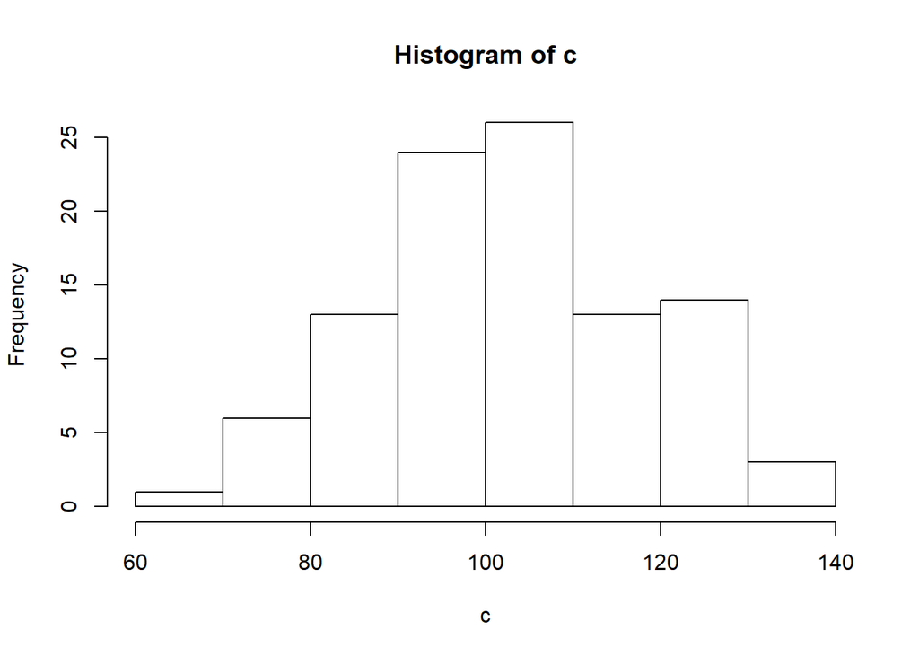

```r
c <- apply(y, 1, function(x) {sum(x^2)})
hist(c)
```

```r
# This is a chi-square distribution
```

#### • (d) the historgrams for each rows in z, where z is a 3x1000 matrix with the entries following standard normal distribution.

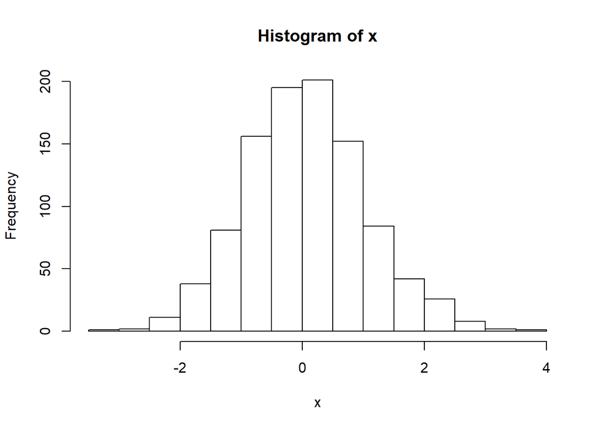

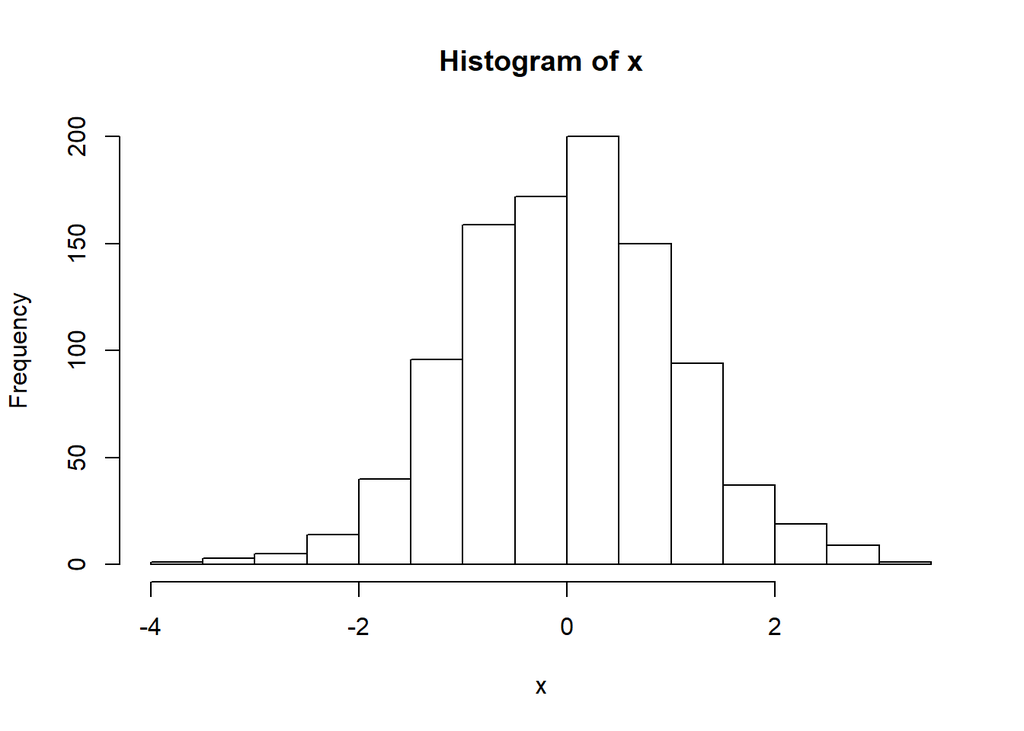

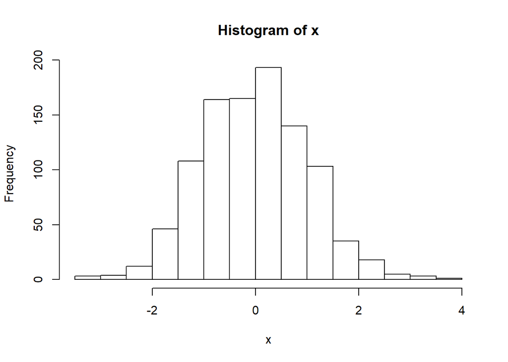

[output not shown]

[output cut: 19 more lines]

[output not shown]

```r
z = matrix(rnorm(3000), nrow=3)

apply(z, 1, function(x){hist(x)})
```

#### 5. Write a function:

#### • input a vector v and a value n

#### • out the original vector with its missing data in v being replaced by n.

#### v could be a numeric or characrer vector and n could be a number or a string. If there is no missing value, return v and the message There is no missing value.

```r
na_replace <- function(v, n) {
  if(sum(is.na(v)) == 0) {
    print(v)
    print("There is no missing value.")
  } else {
    v[is.na(v)] <- n
    v
  }
}

v <- c("1","2","3")
n <- 3
na_replace(v, n)
```

```
## [1] "1" "2" "3"
## [1] "There is no missing value."
```

#### 6. Write a function:

#### • input a numeric vector

#### • output the original vector with its missing data being replaced by the mean of the vector. If there is no missing value, return the original vector with the message There is no missing value.

```r
mean_replace <- function(v) {
  if(sum(is.na(v)) == 0) {
    print(v)
    print("There is no missing value.")
  } else {
    v[is.na(v)] <- mean(v, na.rm=T)
    v
  }
}

v <- c(1,2,3, NA)
mean_replace(v)
```

```
## [1] 1 2 3 2
```

#### 7. Write a function:

#### • input a character/factor vector

#### • output a vector with its missing data being replaced by the mode of the vector. If there is no missing value, return the original vector with the message There is no missing value.

```r
mode_replace <- function(v) {
  if(sum(is.na(v)) == 0) {
    print(v)
    print("There is no missing value.")
  } else {
    v[is.na(v)] <- v[which.max(tabulate(match(v,unique(v))))]
    v
  }
}

v <- c(1,2,2, NA)
mode_replace(v)
```

```
## [1] 1 2 2 2
```

#### 8. Write a function:

#### • output the data frame with numeric missing values being replaced by the corresponding column mean and categorical missing values being replaced by the corresponding column mode.

#### Check to confirm that the function works with the titanic dataset.

```r
library(readr)
titanic <- as.data.frame(read_csv(file = "C:/Users/student/Documents/Senior Year/MATH 421/titanic.csv"))
titanic$Survived <- as.character(titanic$Survived)
titanic$Pclass <- as.character(titanic$Pclass)
sum(is.na(titanic))
```

```
## [1] 866
```

```r
df_mean_replace <- function(d) {
  if(sum(is.na(d)) == 0) {
    print(d)
    print("There are no missing values.")
  } else {
      for (i in 1:length(d)) {
        if(is.numeric(d[,i])){
          d[,i][is.na(d[,i])] <- mean(d[,i], na.rm=T)
        }
        if(is.character(d[,i])) {
          ux <- unique(d[,i])
          tab <- tabulate(match(d[,i], ux))
          d[,i][is.na(d[,i])] <- sample(as.character(d[,i][tab == max(tab)]),1)
        }
      }
  }
  return(d)
}

sum(is.na(df_mean_replace(titanic)))
```

```
## [1] 0
```

#### 9. Write a function that

#### • input two categorical variables

#### • output the a bar chart of one variable color filled by the other variable.

#### Check your function with two categorical variables in the titanic data

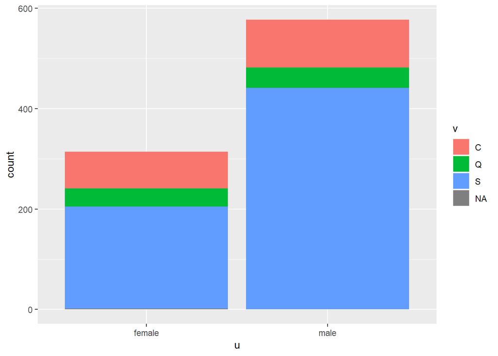

```r
library(ggplot2)
bar_chart <- function(u,v) {
  ggplot(, aes(x=u , fill = v)) +
    geom_bar()
}

bar_chart(titanic$Sex, titanic$Embarked)
```

#### 10. Write a function that

#### • output all the possible bar charts of a categorical variable filled by another categorical variables where both of the two variables must have the number of categories less than 4.

#### Check your function on the titanic data

```r
library(tidyverse)
```

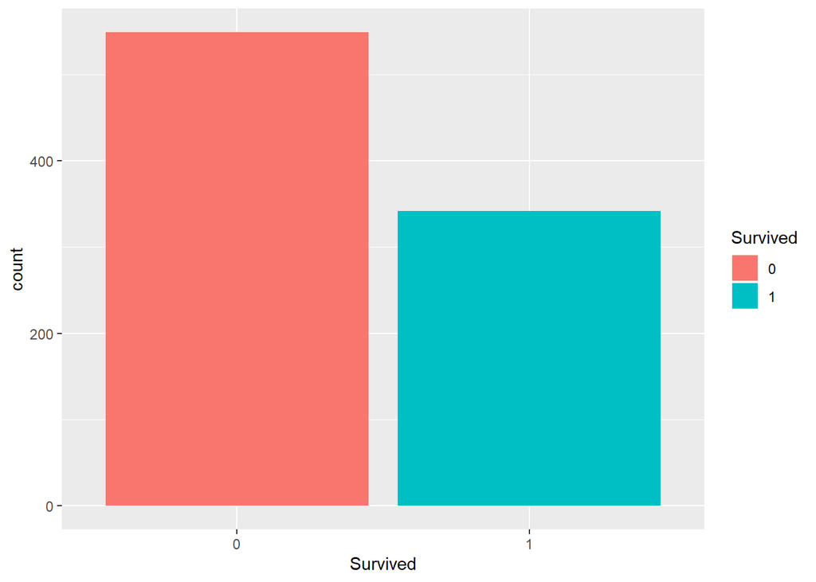

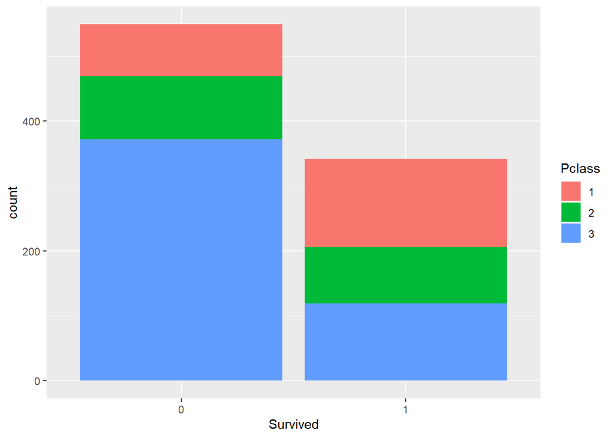

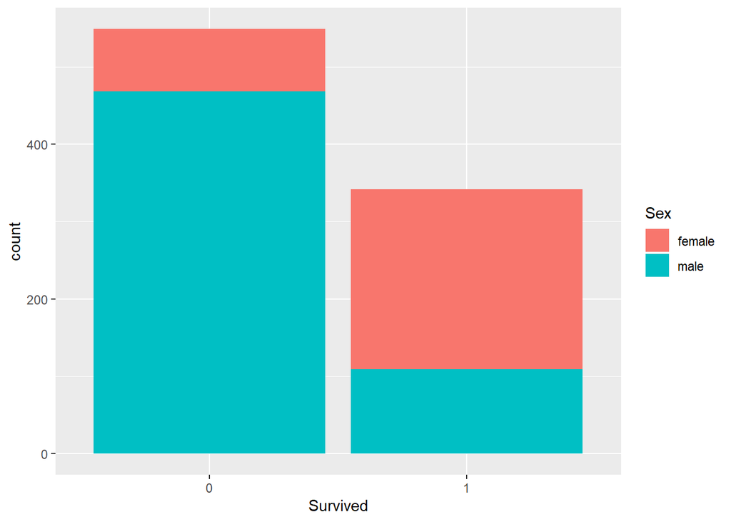

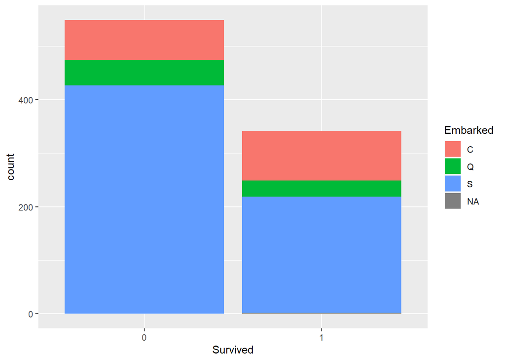

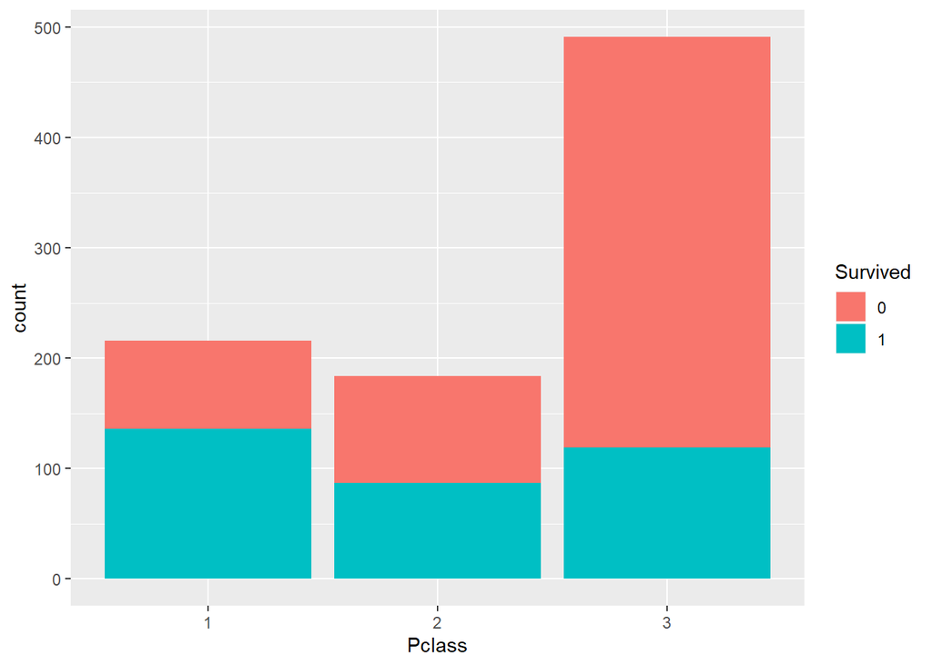

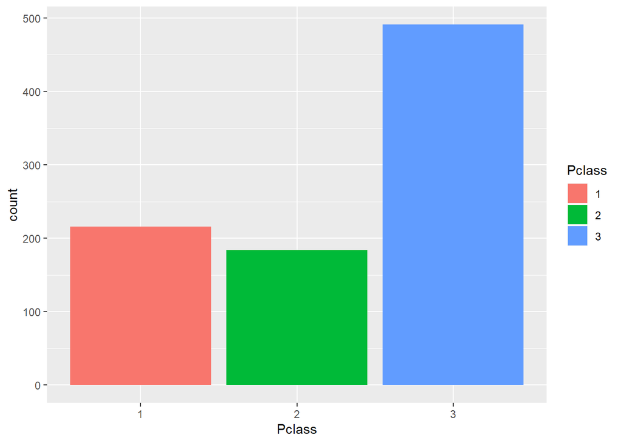

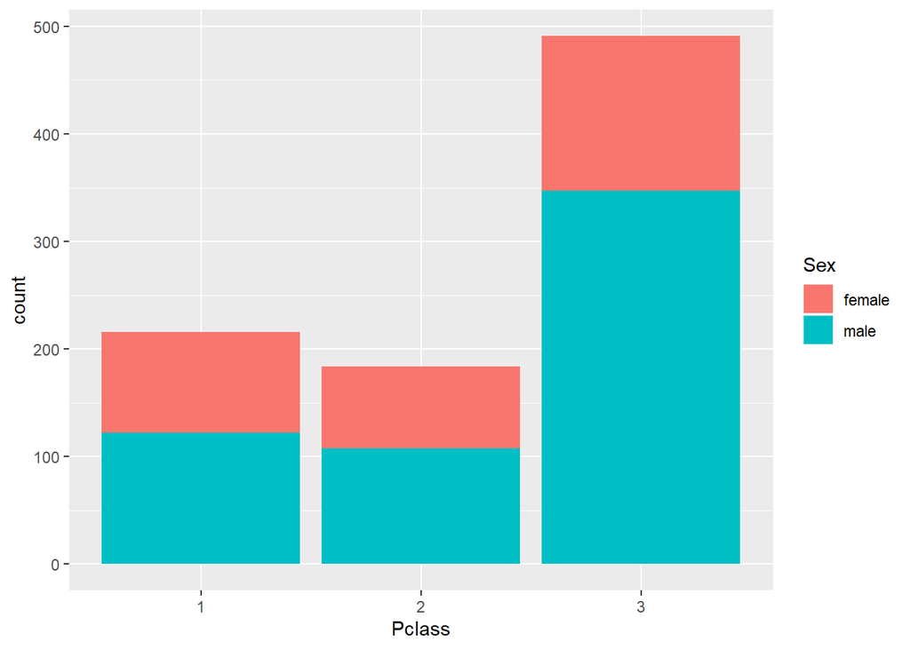

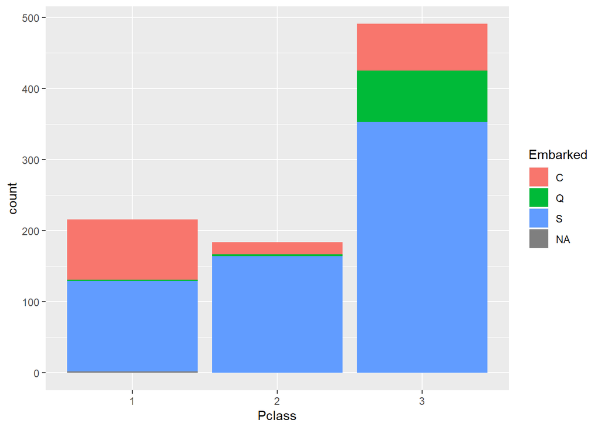

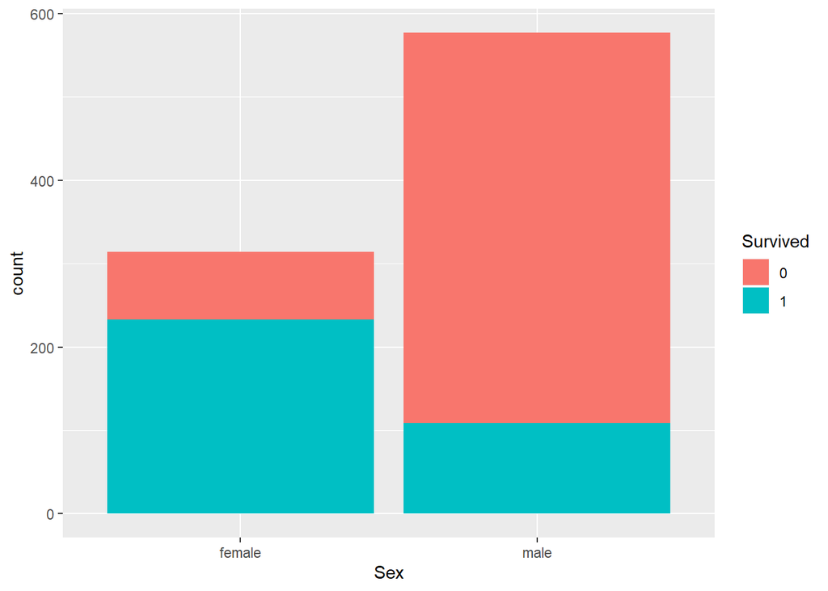

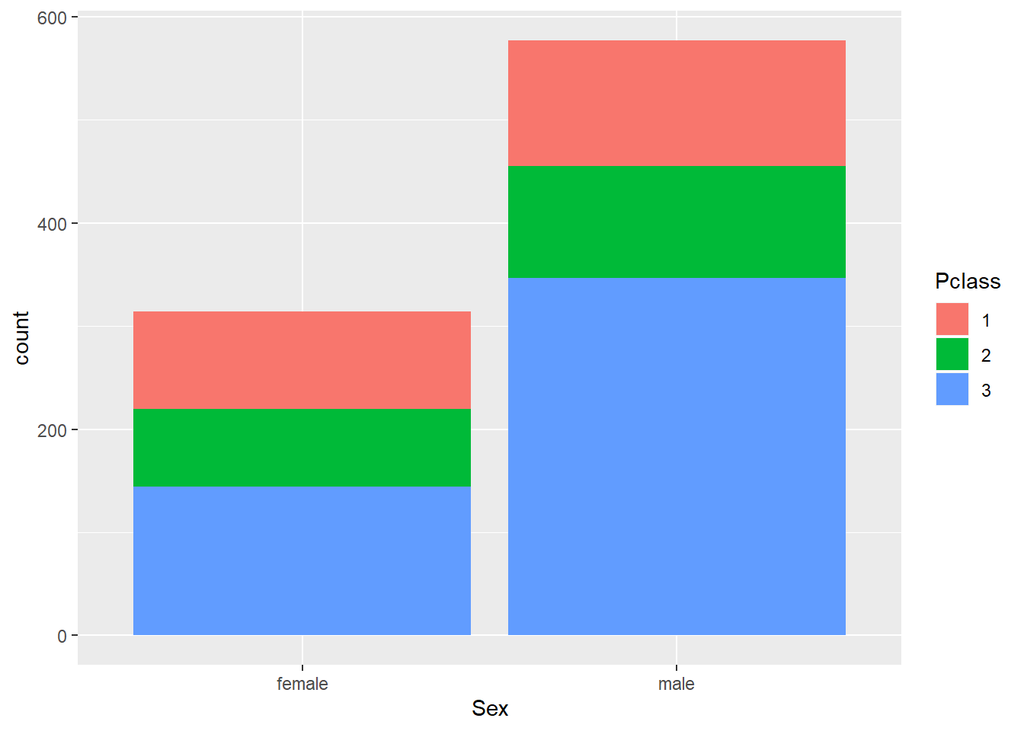

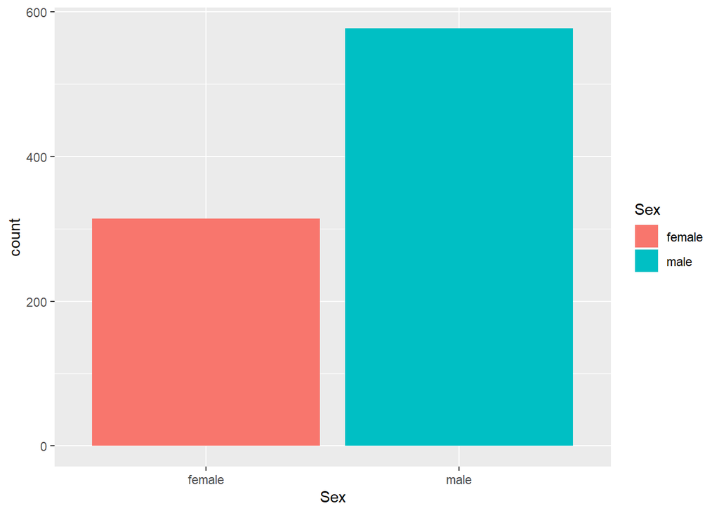

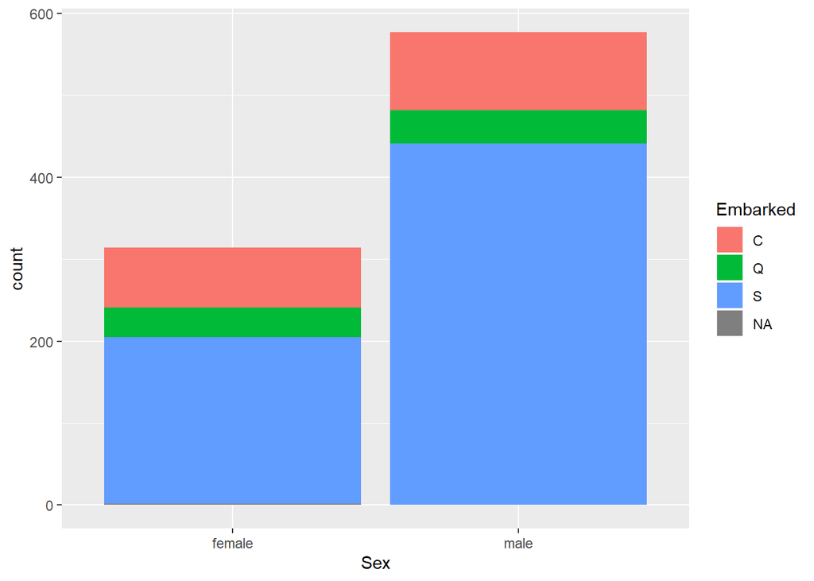

[4 more figures not shown]

```r
all_bar <- function(d) {
  d <- d %>%
    select_if(is.character) %>%
      select_if(~length(table(.)) < 4)
  for (i in 1:length(d)){
    for(j in 1:length(d)) {
      print(ggplot(d, aes(x=d[,i], fill = d[,j])) +
          geom_bar() +
          labs(x= colnames(d[i]),
               fill = names(d[j])))
    }
  }
}
all_bar(titanic)
```

#### 11. Write a function for a quick visualization that input a (cleaned) data and a number k and output the follows

#### • If k = 1, output all the possible bar charts of a categorical variable filled by another categorical variables where both of the two variables must have the number of categories less than 4.

#### • If k = 2, output all the possible density curve (using geom_density), i.e. density curves of all numeric variables

#### • If k = 3, all possible density curves of all numeric variables coloring by a categorical variable with the number of categories less than 4.

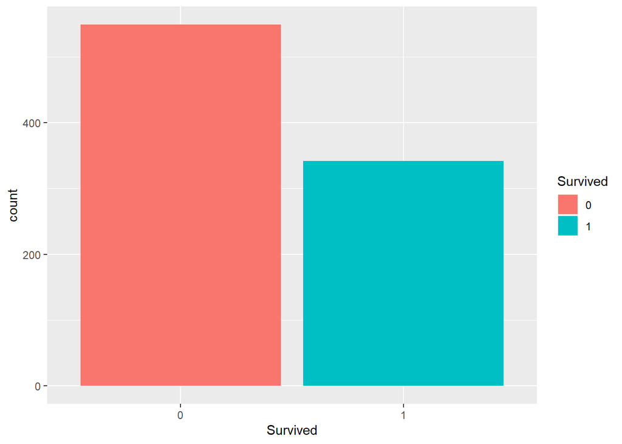

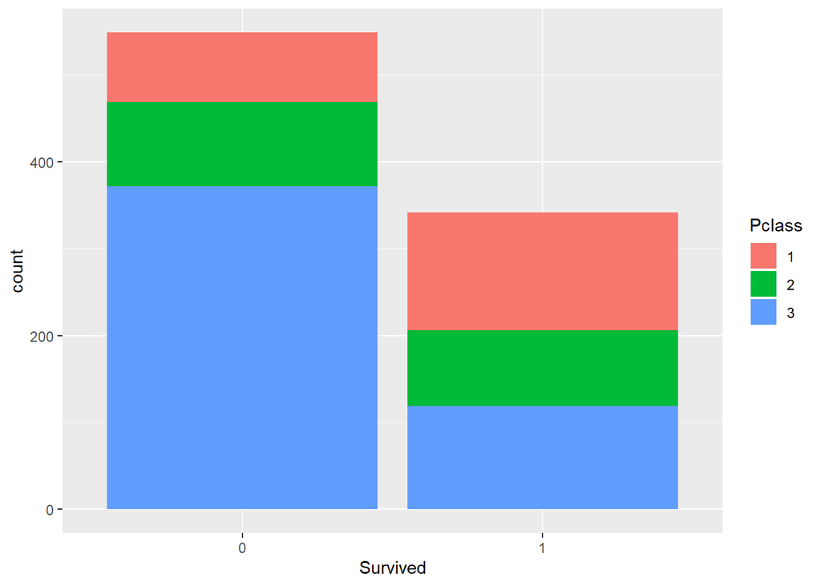

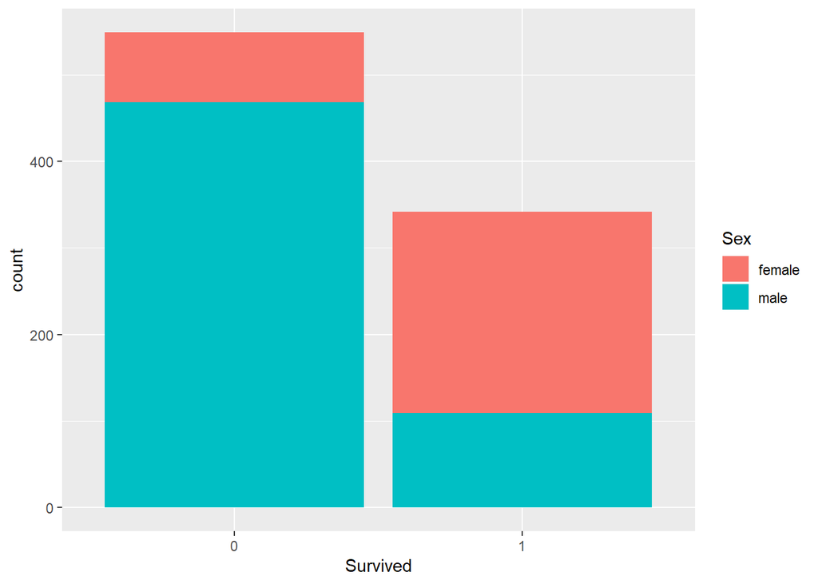

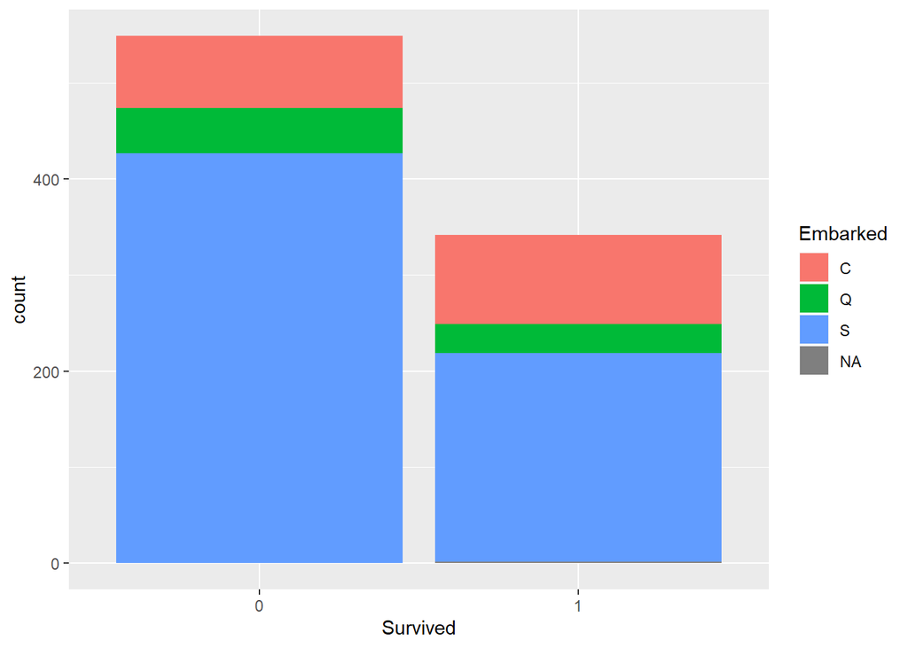

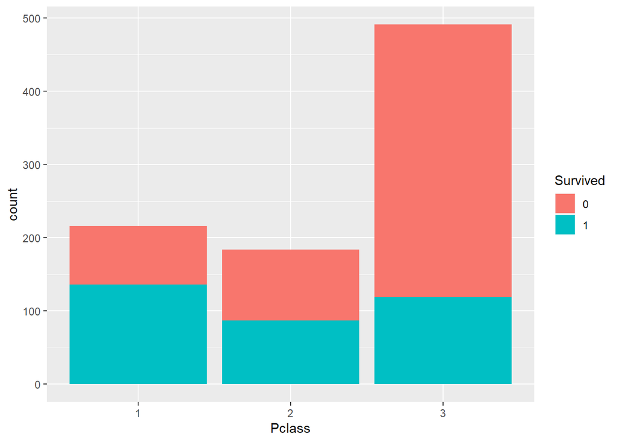

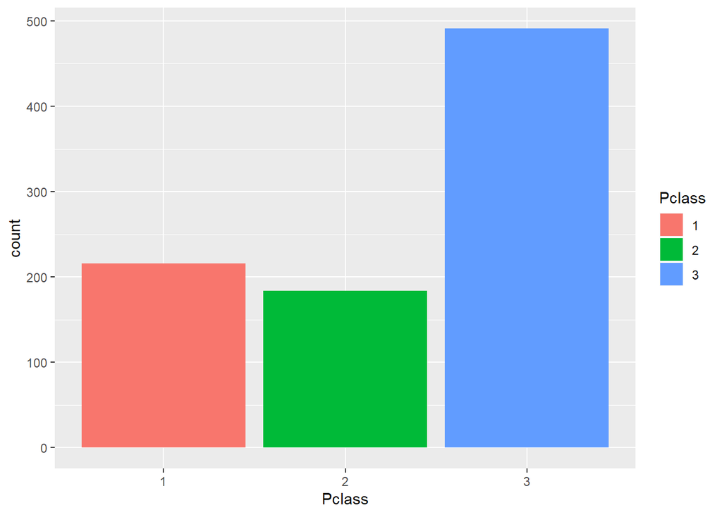

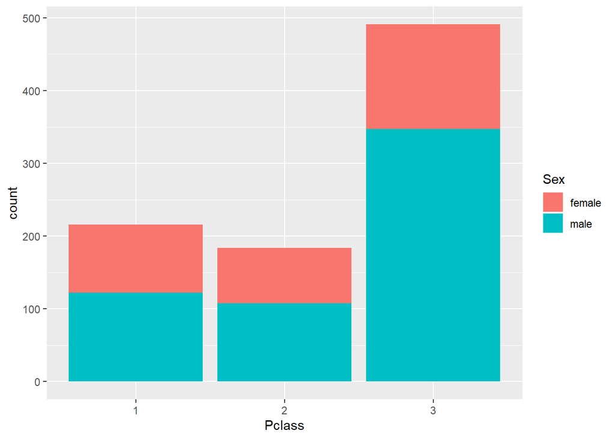

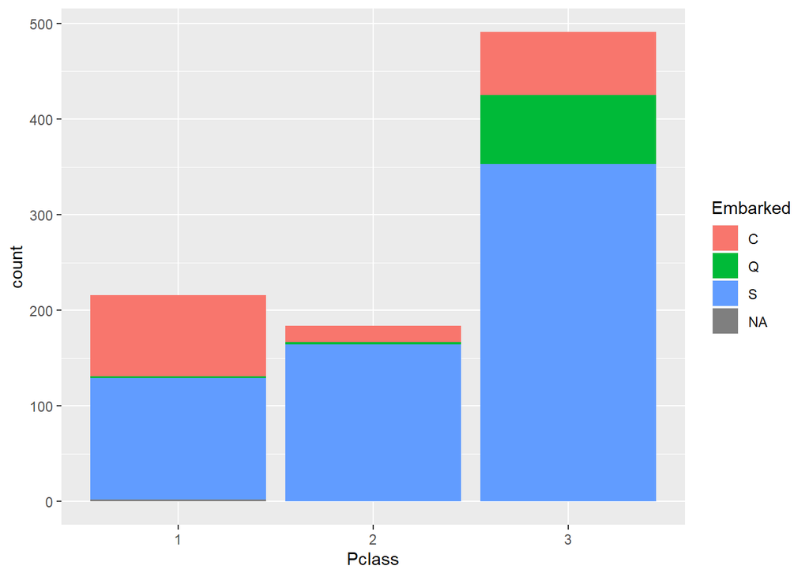

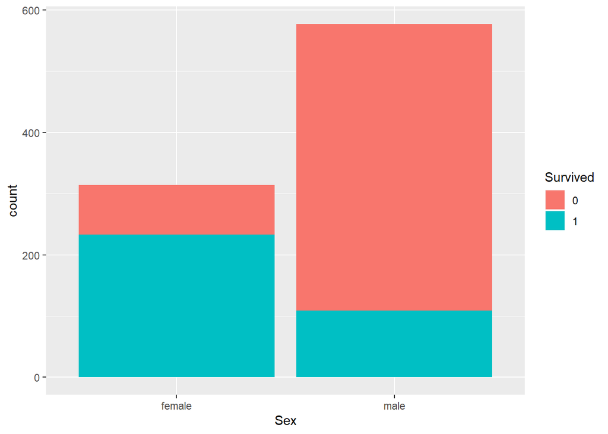

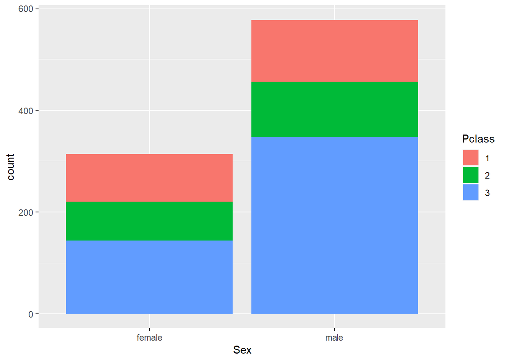

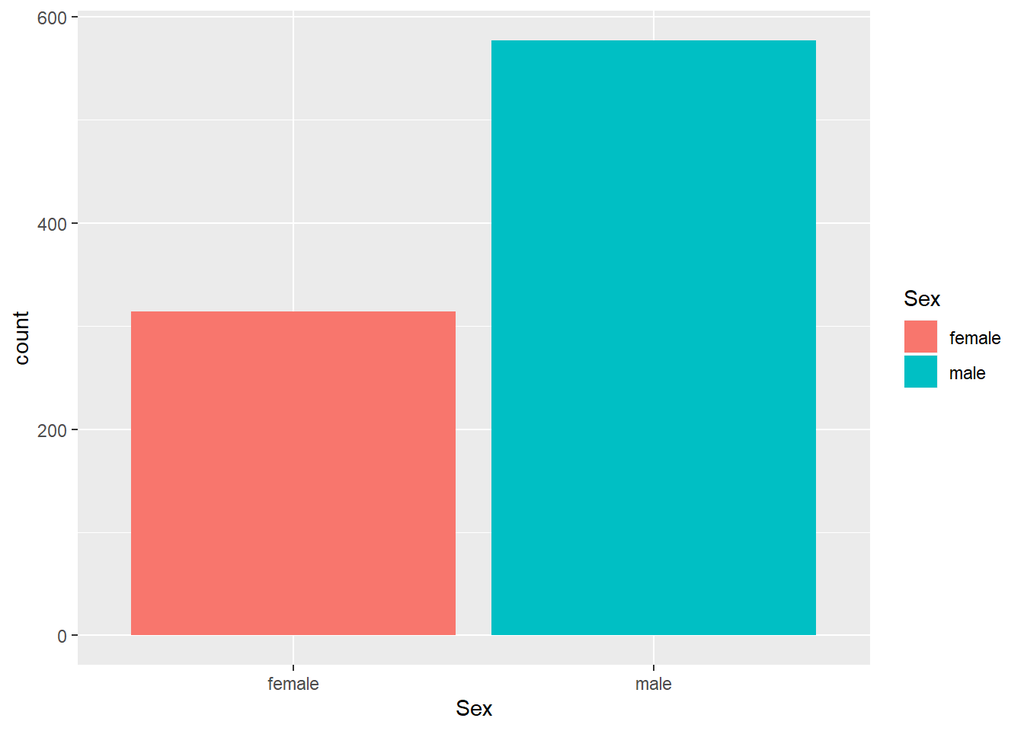

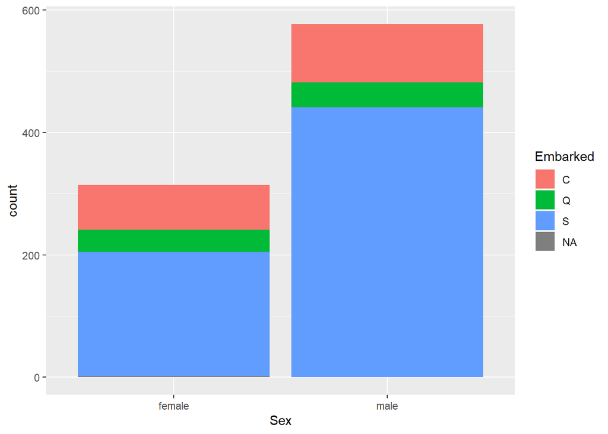

[4 more figures not shown]

```r
k_graphing <- function(d, k) {
  if(k == 1) {
   all_bar(d)
  }
  if(k == 2) {
    d <- d %>%
      select_if(is.numeric)
    for (i in 1:length(d)) {
      print(ggplot(d, aes(x=d[,i])) +
      geom_density() +
        labs(x= colnames(d[i])))
    }
  }
  if(k == 3) {
   dc <- d %>%
      select_if(is.character) %>%
        select_if(~length(table(.)) < 4)
    dn <- d %>%
      select_if(is.numeric)
    for (i in 1:length(dn)) {
      for(j in 1:length(dc)) {
        print(ggplot(, aes(x=dn[,i], color = dc[,j])) +
          geom_density() +
            labs(y= "Density",
                 x = colnames(d[j]), color = names(dc)[j]))
      }

    }
  }
}
k_graphing(titanic, 1)
```